# Ford GoBike data analysis

## by Sameer Ahmed

## Investigation Overview

What are the features affecting trip duration the most ( gender , user type ,weekday)

## Dataset Overview

This data set has information regarding bikes ride made in a bike shop.

## Trip duration distribution

Studying the distribution of trip duration using hist graph. We can interpret from the above plot that majority of riders have a tendency towards using the bikes for a short time durational trips (around 600 seconds)

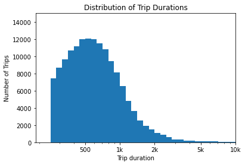

```python
log_binsize = 0.05
bins = 10 ** np.arange(2.4, np.log10(bikes['duration_sec'].max())+log_binsize, log_binsize)
plt.hist(data = bikes , x="duration_sec", bins = bins);
plt.xscale('log')
plt.xticks([500, 1e3, 2e3, 5e3, 1e4], [500, '1k', '2k', '5k', '10k'])
plt.title('Distribution of Trip Durations')
plt.xlabel('Trip duration')
plt.ylabel('Number of Trips')
plt.axis([0, 10000, 0, 15000]);
```

# User type count

I will study user_type specifically count for each type. As shown in graph number of trips done by subscribers are more than customers, this can be a feature affects the trip duratoin.

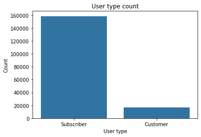

```python
base_color = sb.color_palette()[0]
sb.countplot(data = bikes, x = 'user_type', order = bikes['user_type'].value_counts().index ,color = base_color);
plt.title('User type count')
plt.xlabel('User type')
plt.ylabel('Count');
```

# Member gender count

From the graph we see that males have more entries other than female and other, further study to see the relationship between gender and trip duration.

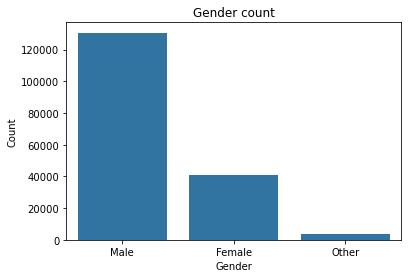

```python
sb.countplot(data = bikes, x = 'member_gender', order = bikes['member_gender'].value_counts().index ,color = base_color);
plt.title('Gender count')
plt.xlabel('Gender')
plt.ylabel('Count');
```

# Exploring number of rides per weekday.

Thursday holds the biggest number of rides while weekend has the lowest number of rides, this can be an affecting feature toward trip duration.

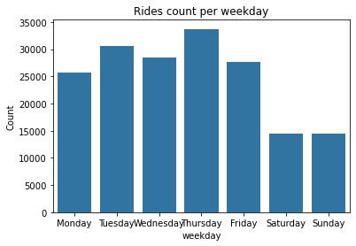

```python
orders = [ 'Monday', 'Tuesday', 'Wednesday', 'Thursday', 'Friday', 'Saturday', 'Sunday']
sb.countplot(data = bikes, x = 'day_of_week', order = orders,color = base_color);
plt.title('Rides count per weekday')
plt.xlabel('weekday')
plt.ylabel('Count');
```

## Trip duration vs. User type

A study between trip duration and user type. Illustrating the relation between user type and trip duration confirming customer user type has longer trip duration than subscriber user type

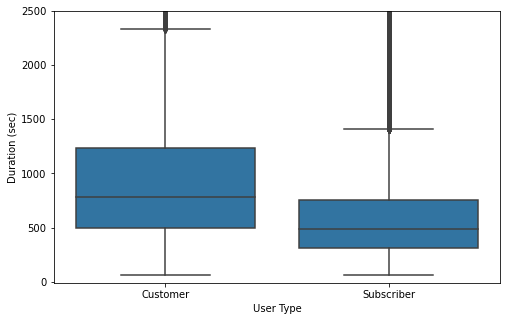

```python
plt.figure(figsize = [8, 5])
sb.boxplot(data = bikes_copy, x = 'user_type', y = 'duration_sec', color = base_color)
plt.ylim([-10, 2500])
plt.xlabel('User Type')
plt.ylabel('Duration (sec)')
plt.show()
```

# trip duration vs. weekdays.

More detailed plot showing longest trips done over the weekend with within range of 850-900 sec with few outliers and weekdays has shorted trips around 750 sec with outliers near 1400.

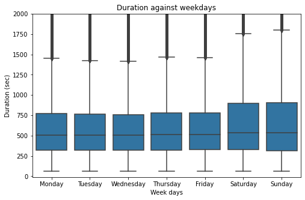

```python
plt.figure(figsize = [8, 5])
base_color = sb.color_palette()[0]
sb.boxplot(data = bikes_copy, x = 'day_of_week', y = 'duration_sec', order=orders,color = base_color)
plt.ylim([-10, 2000])
plt.title('Duration against weekdays')
plt.xlabel('Week days')
plt.ylabel('Duration (sec)');
```